# a3_task3_krista_finlay

Krista Finlay

11/1/2020

### Read in the urchin data

```r
urchin_data <- read_csv(here("data", "urchin_data.csv"))
```

## Section 1: Size comparisons of red and purple sea urchin

(include data from all sites, and all treatments)

### Exploratory data visualization:

a.i. Comparing the distribution of sizes of red and purple urchins using the graph types- histogram and boxplot. - Make a subset from the urchin_data set - Clean column names and select columns size and common_name -Then make ggplot histogram, separating the red and purple urchins using facet_wrap -Label x and y axes

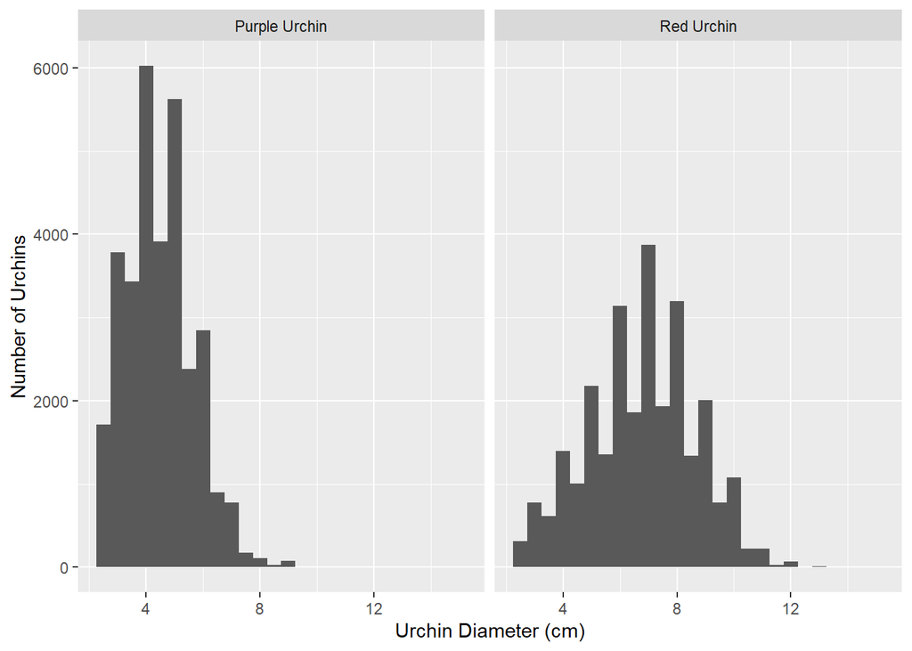

```r
urchin_size <- urchin_data %>%
  clean_names() %>%
  select(size, common_name)

ggplot(data = urchin_size, aes(x = size))+
  geom_histogram(binwidth = 0.5)+
  facet_wrap(~common_name)+
  labs(x = "Urchin Diameter (cm)", y = "Number of Urchins")
```

- Then using the urchin-size data set, make a ggpolt boxplot
- Label the x and y axes

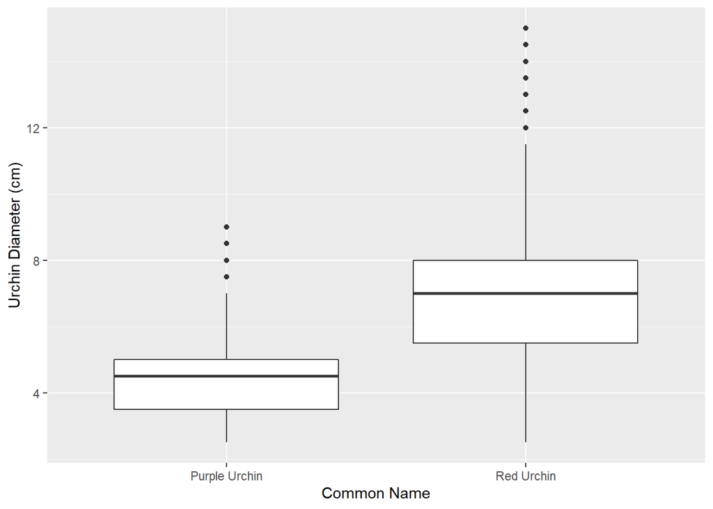

```r
ggplot(data = urchin_size, aes(x = common_name, y = size))+
  geom_boxplot()+
  labs(x = "Common Name", y = "Urchin Diameter (cm)")
```

### Descriptive statistics table

a.ii. Creating a summary table that contains statistics for purple and red urchins: - mean, median, standard deviation, sample size - Use kableExtra to make the table look nicer

```r
urchin_summary <- urchin_size %>%
  group_by(common_name) %>%
  summarize(mean = mean(size), median = median(size), sd = sd(size),n = n())

urchin_summary
```

```
## # A tibble: 2 x 5
##   common_name    mean median    sd     n
##   <chr>         <dbl>  <dbl> <dbl> <int>
## 1 Purple Urchin  4.47    4.5  1.18 31805
## 2 Red Urchin     6.78    7    1.89 27408
```

```r
urchin_summary %>%
  kable(col.names = c("Common Name", "Mean Diameter (cm)", "Median Diameter (cm)", "Standard Deviation", "Sample Size (n)")) %>%
  kable_styling(full_width = FALSE)
```

| Common Name | Mean Diameter (cm) | Median Diameter (cm) | Standard Deviation | Sample Size (n) |
| --- | --- | --- | --- | --- |
| Purple Urchin | 4.469797 | 4.5 | 1.175264 | 31805 |
| Red Urchin | 6.776489 | 7.0 | 1.891343 | 27408 |

### Written description regarding how the size (distribution, central tendancy, spread, etc) compare between the two species of urchins.

```r
#Actual Difference difference in mean urchin diameter between red and purple urchin species
6.776489 - 4.469797
```

```
## [1] 2.306692
```

```r
# The % different in mean urchin diameter between red and purple urchin species
(6.776489- 4.469797)/(6.776489) *100
```

```
## [1] 34.03963
```

Comparing the purple and red urchins sizes in the histograms, the purple urchins appear to be positively skewed with some outlying data, while the red urchins appear to have a more normal symmetric distribution regarding their diameter measurement. I am wondering if there is missing data or samples with the purple urchins to cause their distribution a more skewed shape. According to the histograms, the red urchins appear to have more variability with their wider range of diameter sizes which corresponds to the normal distribution and the location of the mean. The purple urchins have a greater sample size and much larger numbers of counts for specific diameter sizes of urchins than red urchins, which may have contributed to the mean and median being very similar. The percent difference in mean diameter of 34 for the red urchins is a significant amount and can be connected to the range of sizes for red versus purple urchins. The difference in mean and median for both urchins was interesting because I assumed based on the normal graph, that the red urchins would have a mean and median more close in value, however the purple values were closer. The standard deviation values for both urchin species seem to be high, meaning they have a high variance, and it was surprising to see a greater standard deviation for the red urchin data

## section 2: Exploring purple sea urchins by site and year

b.i. Create a subset of the urchins data specific for purple urchins: - filter to only include observations of purple urchins - Convert the date to class “Date” - Create a new column that only contains the year - Create a new column called site_full that contains the full name (not abbreviation) for each of the five sites: NAPL = Naples Reef, AQUE = Arroyo Quemado Reef, CARP = Carpinteria Reef, MOHK = Mohawk Reef, IVEE = Isla Vista Reef.

```r
clean_urchins <- urchin_data %>%
  clean_names()

purple_urchins <- clean_urchins %>%
  filter(common_name == "Purple Urchin") %>%
  mutate(date_new = mdy(date)) %>%
  mutate(urchin_year = year(date_new)) %>%
  mutate(site_full = case_when(site == "NAPL" ~"Naples Reef", site == "AQUE" ~"Arroyo Quemado Reef",
                               site == "CARP" ~"Carpinteria Reef", site == "MOHK" ~"Mohawk Reef",
                               site == "IVEE" ~"Isla Vista Reef"))
```

b.ii. Make a summary table: - containing the total number of purple urchins observed by site and year - starting from purple_urchins that was created above and find counts of observations by group.

```r
purple_urchins_site_yr <- purple_urchins %>%
  group_by(site_full, urchin_year) %>%
  count(site_full)

purple_urchins_site_yr
```

```
## # A tibble: 61 x 3
## # Groups:   site_full, urchin_year [61]
##    site_full           urchin_year     n
##    <chr>                     <dbl> <int>
##  1 Arroyo Quemado Reef        2008    67
##  2 Arroyo Quemado Reef        2009   926
##  3 Arroyo Quemado Reef        2010   921
##  4 Arroyo Quemado Reef        2011   887
##  5 Arroyo Quemado Reef        2012   764
##  6 Arroyo Quemado Reef        2013   434
##  7 Arroyo Quemado Reef        2014   410
##  8 Arroyo Quemado Reef        2015   400
##  9 Arroyo Quemado Reef        2016   342
## 10 Arroyo Quemado Reef        2017   406
## # ... with 51 more rows
```

b.iii. Make an exploratory graph of counts of purple urchins recorded at each site over time for the years included in the study.

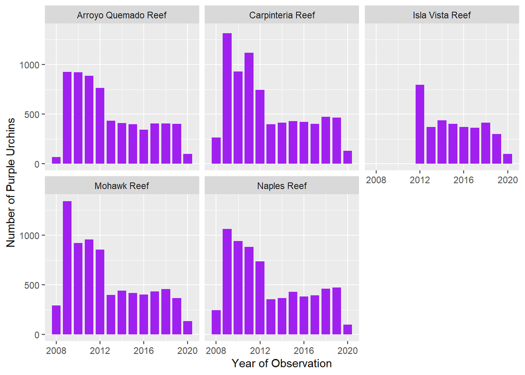

```r
ggplot(data = purple_urchins_site_yr, aes(x = urchin_year, y = n))+
  geom_col(fill = "purple", width = 0.8)+
  facet_wrap(~site_full)+
  labs(x = "Year of Observation", y = "Number of Purple Urchins")+
  theme_gray()
```